# Iris Flower Dataset

### This notebook has been made and produced in jupyter notebook on august 10th 2025, and the last for this dataset was 7 years ago

#### The notebook is being made by José de Jesús Hernández Vázquez

#### Dataset can be found in: https://www.kaggle.com/datasets/arshid/iris-flower-dataset

#### Context according to kaggle "The Iris flower data set is a multivariate data set introduced by the British statistician and biologist Ronald Fisher in his 1936 paper The use of multiple measurements in taxonomic problems. It is sometimes called Anderson's Iris data set because Edgar Anderson collected the data to quantify the morphologic variation of Iris flowers of three related species. The data set consists of 50 samples from each of three species of Iris (Iris Setosa, Iris virginica, and Iris versicolor). Four features were measured from each sample: the length and the width of the sepals and petals, in centimeters."

### 1.- Imports

```python
# Imports
import pandas as pd
import matplotlib.pyplot as plt
import numpy as np
import seaborn as sns
from sklearn.preprocessing import LabelEncoder
from sklearn.preprocessing import StandardScaler
from sklearn.model_selection import train_test_split
from sklearn.metrics import classification_report, confusion_matrix, accuracy_score

# Model Imports
from sklearn.svm import LinearSVC
from sklearn.neighbors import KNeighborsClassifier
from sklearn.ensemble import RandomForestClassifier
```

```python
data = pd.read_csv("/kaggle/input/iris-flower-dataset/IRIS.csv")
```

```python
data.info()
```

```
<class 'pandas.core.frame.DataFrame'>
RangeIndex: 150 entries, 0 to 149
Data columns (total 5 columns):
 #   Column        Non-Null Count  Dtype
---  ------        --------------  -----
 0   sepal_length  150 non-null    float64
 1   sepal_width   150 non-null    float64
 2   petal_length  150 non-null    float64
 3   petal_width   150 non-null    float64
 4   species       150 non-null    object
dtypes: float64(4), object(1)
memory usage: 6.0+ KB
```

### 2.- Cleansing and statistics

#### Although it's widely known this dataset is not missing any data, we still need to verify if there's any need for cleansing. So let's define statistics

```python
mean_sl = data["sepal_length"].mean()
deviation_sl = data["sepal_length"].std()
minimum_sl = data["sepal_length"].min()
maximum_sl = data["sepal_length"].max()


print(f"For sepal length: Mean: {mean_sl} , Standard Deviation: {deviation_sl}, Minimum: {minimum_sl}, Maximum: {maximum_sl}")
```

```
For sepal length: Mean: 5.843333333333334 , Standard Deviation: 0.8280661279778629, Minimum: 4.3, Maximum: 7.9
```

```python
mean_sw = data["sepal_width"].mean()
deviation_sw = data["sepal_width"].std()
minimum_sw = data["sepal_width"].min()
maximum_sw = data["sepal_width"].max()


print(f"For sepal width: Mean: {mean_sw} , Standard Deviation: {deviation_sw}, Minimum: {minimum_sw}, Maximum: {maximum_sw}")
```

```
For sepal width: Mean: 3.0540000000000003 , Standard Deviation: 0.4335943113621737, Minimum: 2.0, Maximum: 4.4
```

```python
mean_pl = data["petal_length"].mean()
deviation_pl = data["petal_length"].std()
minimum_pl = data["petal_length"].min()
maximum_pl = data["petal_length"].max()


print(f"For petal length: Mean: {mean_pl} , Standard Deviation: {deviation_pl}, Minimum: {minimum_pl}, Maximum: {maximum_pl}")
```

```
For petal length: Mean: 3.758666666666666 , Standard Deviation: 1.7644204199522617, Minimum: 1.0, Maximum: 6.9
```

```python
mean_pw = data["petal_width"].mean()
deviation_pw = data["petal_width"].std()
minimum_pw = data["petal_width"].min()
maximum_pw = data["petal_width"].max()


print(f"For petal width: Mean: {mean_pw} , Standard Deviation: {deviation_pw}, Minimum: {minimum_pw}, Maximum: {maximum_pw}")
```

```
For petal width: Mean: 1.1986666666666668 , Standard Deviation: 0.7631607417008414, Minimum: 0.1, Maximum: 2.5
```

### 3.- Visualization

#### Now that we see the statistic parts of petals and sepals (width and length), we can proceed to make it more visually explainative using a Histogram and a Pairplot

##### With an histogram we can actually visualize the distribution of a feature and with the pairplot we can actually see the numeric relation and if there's (if any) visual serpability between classes

#### Histogram

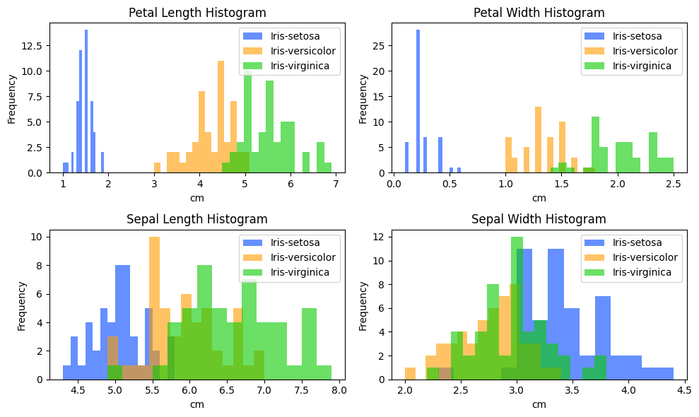

```python
fig, axs = plt.subplots(2,2, figsize = (10,6))

species = data["species"].unique()
colors = ["#0046FF", "#FF9B00", "#08CB00"]

# Variables and titles
features = ["petal_length", "petal_width", "sepal_length", "sepal_width"]
titles = ["Petal Length", "Petal Width", "Sepal Length", "Sepal Width"]


for ax, feature, title in zip(axs.flat, features, titles):
    for sp, color in zip(species, colors):
        subset = data[data["species"] == sp]
        ax.hist(subset[feature], bins = 15, alpha = 0.6, label=sp, color=color)
    ax.set_title(f"{title} Histogram")
    ax.set_xlabel("cm")
    ax.set_ylabel("Frequency")
    ax.legend()

plt.tight_layout()
plt.show()
```

##### When it comes to **petal length** we can totally see how iris setosa shows petals with a size minor to 2cm, which allows us to easily discrimante it, while versicolor and virginica are more difficult to tell apart since they're both in the region between 4 and 5 cm. We can also do this for **petal width** since setosa is at 0.5 or lower, while versicolor and virginica are somewhere between the 1.5 region. When it comes to **sepal length and width** we can see it's where the three species are having almost the same values and overlapping each other, meaning that this isn't actually a good feature to use for discrimination.

#### Pairplot

[output not shown]

[output cut: 14 more lines]

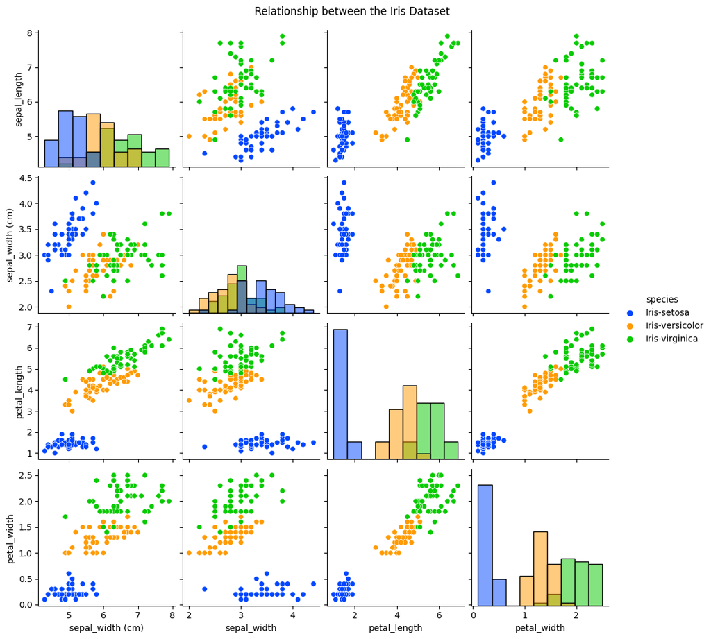

```python
palette = {"Iris-setosa": "#0046FF", "Iris-versicolor": "#FF9B00", "Iris-virginica": "#08CB00"}

# Creating the pairplot

pair = sns.pairplot(data, hue = "species", palette=palette, diag_kind="hist")

# Titles in the axes
for i, feature in enumerate(features):
    pair.axes[1,0].set_ylabel(f"{feature} (cm)")
    pair.axes[-1,0].set_xlabel(f"{feature} (cm)")

# Adding general title

pair.fig.suptitle("Relationship between the Iris Dataset", y=1.02)

plt.show()
```

##### When it comes to the pairplot the biggest difference can be seen also in setosa, this in the relationship between Petal Widnd Length, we can see setosa in a whole different cluster than the other two species but when it comes to sepal length and width, this again isn't a great feature to use for discirimination since we can appreciate that there's a lot of overlapping between species.

##### In this moment we can actually deduct that relationships between petal length and width can be highly discriminative, while on the side of sepal it's the total opposite. This can actually be validated in the future while training models y analyzing the importance of said variables

### 4.- Preprocessing and model training

```python
# Separate characteristics
X = data[["petal_length", "petal_width", "sepal_length", "sepal_width"]]
y = data["species"]
```

```python
# Code the objective variable (in this case species)

le = LabelEncoder()
y_encoded = le.fit_transform(y)
```

```python
# Divide data into train and test

X_train, X_test, y_train, y_test = train_test_split(
    X, y_encoded, test_size=0.2, random_state=42, stratify=y_encoded
)
```

```python
# Escalate characteristics
scaler = StandardScaler()
X_train_scaled = scaler.fit_transform(X_train)
X_test_scaled = scaler.transform(X_test)
```

```python
# Create and train LinearSVC model
model = LinearSVC(random_state=42, max_iter=10000)
model.fit(X_train_scaled, y_train)
```

```
LinearSVC(max_iter=10000, random_state=42)
```

### 5.- Model Comparison

##### I've decided to use LinearSVC thanks to a guide from scikit-learn (https://scikit-learn.org/1.3/tutorial/machine_learning_map/) however I want to test LinearSVC against some more popular models bieng this Random Forest and KNN

```python
X = data[["petal_length", "petal_width", "sepal_length", "sepal_width"]]
y = data["species"]

le = LabelEncoder()
y_encoded = le.fit_transform(y)

X_train, X_test, y_train, y_test = train_test_split(
    X, y_encoded, test_size=0.2, random_state=42, stratify=y_encoded
)

scaler = StandardScaler()
X_train_scaled = scaler.fit_transform(X_train)
X_test_scaled = scaler.transform(X_test)
```

```python
models = [
    ("LinearSVC", LinearSVC(max_iter=10000, random_state=42)),
    ("KNN", KNeighborsClassifier()),
    ("RandomForest", RandomForestClassifier(random_state=42))
    ]
```

```python
# Train, predict and evaluate each model
results = []


for name , model in models:
    if name in ["LinearSVC", "KNN"]:
        model.fit(X_train_scaled, y_train)
        preds = model.predict(X_test_scaled)
    else:
        model.fit(X_train, y_train)
        preds = model.predict(X_test)

    # Metrics

    acc = accuracy_score(y_test, preds)
    results.append((name, acc))

    print(f"\n{name}")
    print(f"Accuracy: {acc:.3f}")
    print(f"Confussion Matrix:\n", confusion_matrix(y_test, preds))
    print(f"Classification Report:\n", classification_report(y_test, preds, target_names=le.classes_, zero_division=0))
```

```
LinearSVC
Accuracy: 0.900
Confussion Matrix:
 [[10  0  0]
 [ 0  8  2]
 [ 0  1  9]]
Classification Report:
                  precision    recall  f1-score   support

    Iris-setosa       1.00      1.00      1.00        10
Iris-versicolor       0.89      0.80      0.84        10
 Iris-virginica       0.82      0.90      0.86        10

       accuracy                           0.90        30
      macro avg       0.90      0.90      0.90        30
   weighted avg       0.90      0.90      0.90        30


KNN
Accuracy: 0.933
Confussion Matrix:
 [[10  0  0]
 [ 0 10  0]
 [ 0  2  8]]
Classification Report:
                  precision    recall  f1-score   support

    Iris-setosa       1.00      1.00      1.00        10
Iris-versicolor       0.83      1.00      0.91        10
 Iris-virginica       1.00      0.80      0.89        10

       accuracy                           0.93        30
      macro avg       0.94      0.93      0.93        30
   weighted avg       0.94      0.93      0.93        30


RandomForest
Accuracy: 0.933
Confussion Matrix:
 [[10  0  0]
 [ 0  9  1]
 [ 0  1  9]]
Classification Report:
                  precision    recall  f1-score   support

    Iris-setosa       1.00      1.00      1.00        10
Iris-versicolor       0.90      0.90      0.90        10
 Iris-virginica       0.90      0.90      0.90        10

       accuracy                           0.93        30
      macro avg       0.93      0.93      0.93        30
   weighted avg       0.93      0.93      0.93        30
```

### 6.- Best model

##### First of all let's point out that this was the best model according to the techniques and data that I used, this does not exclusiveley mean that the model that turns out the best for this case will always be the best for all similar cases

```python
results_df = pd.DataFrame(results, columns=["Model", "Accuracy"]).sort_values(by="Accuracy", ascending=False)
print("\nMetrics Brief:\n", results_df)
```

```
Metrics Brief:
           Model  Accuracy
1           KNN  0.933333
2  RandomForest  0.933333
0     LinearSVC  0.900000
```

```python
best_model_name = results_df.iloc[0]["Model"]
print(f"\nBest Model: {best_model_name}")
```

```
Best Model: KNN
```

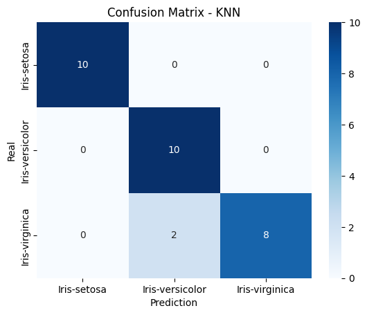

```python
# Select date if scalation is needed

if best_model_name in ["LinearSVC", "KNN"]:
    best_model = [m for m in models if m[0] == best_model_name][0][1]
    best_model.fit(X_train_scaled, y_train)
    preds_best = best_model.predict(X_test_scaled)
else:
    best_model = [m for m in models if m[0] == best_model_name][0][1]
    best_model.fit(X_train, y_train)
    preds_best = best_model.predict(X_test)

cm = confusion_matrix(y_test, preds_best)
sns.heatmap(cm, annot=True, fmt="d", cmap="Blues",
            xticklabels=le.classes_,
            yticklabels=le.classes_)
plt.title(f"Confusion Matrix - {best_model_name}")
plt.xlabel("Prediction")
plt.ylabel("Real")
plt.show()
```

### 7. Decision boundaries

```python
# We'll use just 2 features to graph in 2D

feat_x = "petal_length"
feat_y = "petal_width"
X_2d = data[[feat_x, feat_y]]
y_2d = le.fit_transform(data["species"])

X_train2d, X_test2d, y_train2d, y_test2d = train_test_split(
    X_2d, y_2d, test_size=0.2, random_state=42, stratify=y_2d
)

scaler2d = StandardScaler()
X_train2d_scaled = scaler2d.fit_transform(X_train2d)
X_test2d_scaled = scaler2d.transform(X_test2d)
```

```python
### Let's retrain the best model but just using 2 variables

if best_model_name in ["LinearSVC", "KNN"]:
    best_model.fit(X_train2d_scaled, y_train2d)
    X_plot = X_train2d_scaled
else:
    best_model.fit(X_train2d, y_train2d)
    X_plot = X_train2d
```

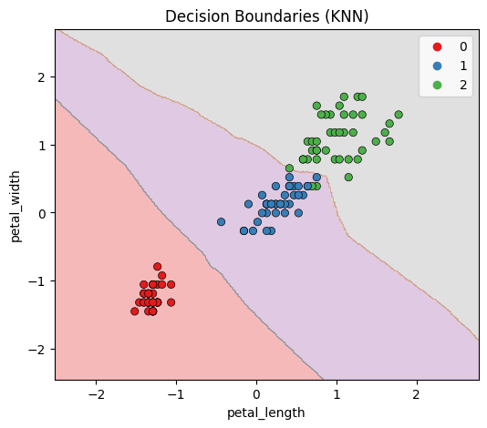

```python
# Graphing limits

x_min, x_max = X_plot[:, 0].min() - 1, X_plot[:, 0].max() + 1
y_min, y_max = X_plot[:, 1].min() - 1, X_plot[:, 1].max() + 1
xx, yy = np.meshgrid(np.linspace(x_min, x_max, 300),
                     np.linspace(y_min, y_max, 300))

if best_model_name in ["LinearSVC", "KNN"]:
    Z = best_model.predict(np.c_[xx.ravel(), yy.ravel()])
else:
    Z = best_model.predict(np.c_[xx.ravel(), yy.ravel()])

Z = Z.reshape(xx.shape)

plt.figure(figsize=(6,5))
plt.contourf(xx, yy, Z, alpha=0.3, cmap=plt.cm.Set1)
sns.scatterplot(x=X_plot[:,0], y=X_plot[:,1], hue=y_train2d, palette="Set1", edgecolor='k')
plt.xlabel(feat_x)
plt.ylabel(feat_y)
plt.title(f"Decision Boundaries ({best_model_name})")
plt.show()
```

#### Just for testing, we'll do the relevance of variables using randomforest

```python
rf = RandomForestClassifier(random_state=42)
rf.fit(X_train, y_train)
importances = rf.feature_importances_

# DataFrame de importancia
feature_importance_df = pd.DataFrame({
    "Feature": X.columns,
    "Importance": importances
}).sort_values(by="Importance", ascending=False)
```

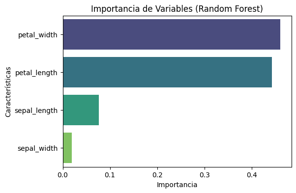

```python
# Graphing
plt.figure(figsize=(6,4))
sns.barplot(data=feature_importance_df, x="Importance", y="Feature", palette="viridis")
plt.title("Importancia de Variables (Random Forest)")
plt.xlabel("Importancia")
plt.ylabel("Características")
plt.show()
```

### 8. Conclusion

```python
results_df = pd.DataFrame(results, columns=["Model", "Accuracy"]).sort_values(by="Accuracy", ascending=False)
print("\nMetrics brief:\n", results_df)

best_model_name = results_df.iloc[0]["Model"]
best_acc = results_df.iloc[0]["Accuracy"]

top_feature = feature_importance_df.iloc[0]["Feature"]
second_feature = feature_importance_df.iloc[1]["Feature"]
```

```
Metrics brief:
           Model  Accuracy
1           KNN  0.933333
2  RandomForest  0.933333
0     LinearSVC  0.900000
```

```python
print(f"\nConclusion:")
print(f"The best performin model was **{best_model_name}** with an accuracy of {best_acc:.3f}.")
print(f"Accoding to random forest, the most important features were '{top_feature}' and '{second_feature}', which confirms that petals characteristics has more weight than sepals")
```

```
Conclusion:
The best performin model was **KNN** with an accuracy of 0.933.
Accoding to random forest, the most important features were 'petal_width' and 'petal_length', which confirms that petals characteristics has more weight than sepals
```